# Lending Club Loan Data Analysis

```python
import numpy as np
import pandas as pd
import matplotlib.pyplot as plt
import seaborn as sns
from sklearn.preprocessing import LabelEncoder
from sklearn.model_selection import train_test_split
from imblearn.over_sampling import RandomOverSampler
from sklearn.linear_model import LogisticRegression
from sklearn.metrics import accuracy_score
from sklearn.ensemble import RandomForestClassifier
from sklearn.neighbors import KNeighborsClassifier
from keras.models import Sequential
from keras.layers import Dense
from keras.layers import Dropout
plt.rcParams['figure.figsize'] = (10,10)
```

### **Step 1. Import Data File**

```python
loan_df = pd.read_csv('loan_data.csv')
loan_df.shape
```

```
(9578, 14)
```

### **Step 2. Data Preprocessing**

**2.1 Check Top 5 Rows**

```python
loan_df.head()
```

|  | credit.policy | purpose | int.rate | installment | log.annual.inc | dti | fico | days.with.cr.line | revol.bal | revol.util | inq.last.6mths | delinq.2yrs | pub.rec | not.fully.paid |
| --- | --- | --- | --- | --- | --- | --- | --- | --- | --- | --- | --- | --- | --- | --- |
| 0 | 1 | debt_consolidation | 0.1189 | 829.10 | 11.350407 | 19.48 | 737 | 5639.958333 | 28854 | 52.1 | 0 | 0 | 0 | 0 |
| 1 | 1 | credit_card | 0.1071 | 228.22 | 11.082143 | 14.29 | 707 | 2760.000000 | 33623 | 76.7 | 0 | 0 | 0 | 0 |
| 2 | 1 | debt_consolidation | 0.1357 | 366.86 | 10.373491 | 11.63 | 682 | 4710.000000 | 3511 | 25.6 | 1 | 0 | 0 | 0 |
| 3 | 1 | debt_consolidation | 0.1008 | 162.34 | 11.350407 | 8.10 | 712 | 2699.958333 | 33667 | 73.2 | 1 | 0 | 0 | 0 |
| 4 | 1 | credit_card | 0.1426 | 102.92 | 11.299732 | 14.97 | 667 | 4066.000000 | 4740 | 39.5 | 0 | 1 | 0 | 0 |

**2.2 Check Data Stats**

```python
loan_df.describe()
```

|  | credit.policy | int.rate | installment | log.annual.inc | dti | fico | days.with.cr.line | revol.bal | revol.util | inq.last.6mths | delinq.2yrs | pub.rec | not.fully.paid |
| --- | --- | --- | --- | --- | --- | --- | --- | --- | --- | --- | --- | --- | --- |
| count | 9578.000000 | 9578.000000 | 9578.000000 | 9578.000000 | 9578.000000 | 9578.000000 | 9578.000000 | 9.578000e+03 | 9578.000000 | 9578.000000 | 9578.000000 | 9578.000000 | 9578.000000 |
| mean | 0.804970 | 0.122640 | 319.089413 | 10.932117 | 12.606679 | 710.846314 | 4560.767197 | 1.691396e+04 | 46.799236 | 1.577469 | 0.163708 | 0.062122 | 0.160054 |
| std | 0.396245 | 0.026847 | 207.071301 | 0.614813 | 6.883970 | 37.970537 | 2496.930377 | 3.375619e+04 | 29.014417 | 2.200245 | 0.546215 | 0.262126 | 0.366676 |
| min | 0.000000 | 0.060000 | 15.670000 | 7.547502 | 0.000000 | 612.000000 | 178.958333 | 0.000000e+00 | 0.000000 | 0.000000 | 0.000000 | 0.000000 | 0.000000 |
| 25% | 1.000000 | 0.103900 | 163.770000 | 10.558414 | 7.212500 | 682.000000 | 2820.000000 | 3.187000e+03 | 22.600000 | 0.000000 | 0.000000 | 0.000000 | 0.000000 |
| 50% | 1.000000 | 0.122100 | 268.950000 | 10.928884 | 12.665000 | 707.000000 | 4139.958333 | 8.596000e+03 | 46.300000 | 1.000000 | 0.000000 | 0.000000 | 0.000000 |
| 75% | 1.000000 | 0.140700 | 432.762500 | 11.291293 | 17.950000 | 737.000000 | 5730.000000 | 1.824950e+04 | 70.900000 | 2.000000 | 0.000000 | 0.000000 | 0.000000 |
| max | 1.000000 | 0.216400 | 940.140000 | 14.528354 | 29.960000 | 827.000000 | 17639.958330 | 1.207359e+06 | 119.000000 | 33.000000 | 13.000000 | 5.000000 | 1.000000 |

**2.3 Check for Null Values**

```python
loan_df.isna().sum().sum()
#No Null Values Present in Dataset
```

```
0
```

**2.4 Check for Unique Values in Columns**

```python
for col in loan_df.columns:
    print("Unique values in {} Column are".format(col), loan_df[col].unique())
    print("-----------------------------------------------------------------")
```

```
Unique values in credit.policy Column are [1 0]
-----------------------------------------------------------------
Unique values in purpose Column are ['debt_consolidation' 'credit_card' 'all_other' 'home_improvement'
 'small_business' 'major_purchase' 'educational']
-----------------------------------------------------------------
Unique values in int.rate Column are [0.1189 0.1071 0.1357 0.1008 0.1426 0.0788 0.1496 0.1114 0.1134 0.1221
 0.1347 0.1324 0.0859 0.0714 0.0863 0.1103 0.1317 0.0894 0.1039 0.1513
 0.08   0.1355 0.1229 0.0901 0.0743 0.1375 0.0807 0.1028 0.087  0.1122
 0.0996 0.0933 0.0838 0.0775 0.1059 0.1596 0.1154 0.1343 0.1249 0.0964
 0.1186 0.1501 0.128  0.1091 0.1217 0.1533 0.0712 0.1438 0.1565 0.1467
 0.1312 0.147  0.1407 0.1014 0.1046 0.133  0.0983 0.1393 0.092  0.1236
 0.1362 0.1078 0.1583 0.1109 0.1141 0.1267 0.1204 0.0951 0.1172 0.1299
 0.1488 0.152  0.1425 0.1836 0.1615 0.06   0.0832 0.1261 0.0945 0.1197
 0.1387 0.0976 0.1292 0.0737 0.0768 0.1166 0.1418 0.1545 0.1482 0.1703
 0.145  0.1671 0.1576 0.1608 0.164  0.1734 0.1051 0.157  0.1222 0.1273
 0.1379 0.1253 0.1128 0.1286 0.1287 0.097  0.1001 0.1538 0.1191 0.1254
 0.1159 0.138  0.1096 0.1064 0.1349 0.1033 0.1475 0.1601 0.1507 0.1412
 0.1633 0.1696 0.1146 0.1304 0.1272 0.1209 0.1083 0.1178 0.1241 0.1588
 0.0907 0.102  0.1336 0.1557 0.0938 0.1493 0.1462 0.1367 0.0963 0.1126
 0.1442 0.1148 0.1399 0.1525 0.143  0.1392 0.1904 0.1872 0.162  0.1715
 0.1568 0.0988 0.1062 0.1746 0.0932 0.1411 0.1505 0.1316 0.16   0.1158
 0.1284 0.1095 0.1695 0.1474 0.1537 0.1632 0.0751 0.1422 0.1218 0.1663
 0.1726 0.1853 0.1348 0.1531 0.1635 0.179  0.1758 0.1843 0.1821 0.1183
 0.074  0.1682 0.0774 0.1322 0.2086 0.1461 0.1311 0.1916 0.1884 0.1607
 0.2011 0.167  0.1979 0.1739 0.1704 0.1913 0.1774 0.0705 0.1878 0.1809
 0.2017 0.1982 0.1947 0.2121 0.1459 0.1385 0.1025 0.1099 0.1136 0.2052
 0.1719 0.0639 0.1645 0.0676 0.1793 0.209  0.2016 0.183  0.1941 0.1756
 0.1691 0.1754 0.1722 0.1628 0.1786 0.1659 0.1741 0.1709 0.1457 0.1804
 0.1646 0.1551 0.1772 0.1829 0.1861 0.1797 0.1766 0.1854 0.1665 0.1791
 0.1886 0.1759 0.1443 0.1728 0.1936 0.1683 0.1778 0.2164 0.1867]
-----------------------------------------------------------------
Unique values in installment Column are [829.1  228.22 366.86 ... 161.01 257.7  853.43]
-----------------------------------------------------------------
Unique values in log.annual.inc Column are [11.35040654 11.08214255 10.37349118 ... 12.29225034 10.99909533
 10.11047245]
-----------------------------------------------------------------
Unique values in dti Column are [19.48 14.29 11.63 ... 10.31 23.74 24.05]
-----------------------------------------------------------------
Unique values in fico Column are [737 707 682 712 667 727 722 677 662 767 747 702 672 797 772 782 802 812
 742 692 777 762 757 787 717 752 792 627 687 697 732 822 632 807 817 827
 642 647 652 657 637 612 617 622]
-----------------------------------------------------------------
Unique values in days.with.cr.line Column are [ 5639.958333  2760.        4710.       ...  3423.041667  5916.
 10474.      ]
-----------------------------------------------------------------
Unique values in revol.bal Column are [28854 33623  3511 ...   184 10036 37879]
-----------------------------------------------------------------
Unique values in revol.util Column are [ 52.1   76.7   25.6  ... 104.3  106.4   69.14]
-----------------------------------------------------------------
Unique values in inq.last.6mths Column are [ 0  1  2  3  4  5  6  8  7 33  9 18 14 15 13 12 10 19 11 16 20 27 25 28
 31 24 17 32]
-----------------------------------------------------------------
Unique values in delinq.2yrs Column are [ 0  1  2  4  3  5  6 13  7  8 11]
-----------------------------------------------------------------
Unique values in pub.rec Column are [0 1 2 3 4 5]
-----------------------------------------------------------------
Unique values in not.fully.paid Column are [0 1]
-----------------------------------------------------------------
```

Training Data Observation with above command

- Credit Policy and Not Fully Paid columns are binary columns
- Purpose Columns is the only Categorical Column
- All the other columns has numerical values
- Target variable is binary - 0's and 1's

**2.5 Perform Label Encoding for Categorical Columns**

```python
loan_df_unchanged = loan_df.copy()
```

```python
df_dtypes = loan_df.dtypes.reset_index()
df_dtypes.columns=['count', 'dtype']
grpd_df = df_dtypes.groupby('dtype').aggregate('count').reset_index()
grpd_df
```

|  | dtype | count |
| --- | --- | --- |
| 0 | int64 | 7 |
| 1 | float64 | 6 |
| 2 | object | 1 |

```python
encoding_col_list = df_dtypes[df_dtypes.dtype==object]['count'].values
encoding_col_list
```

```
array(['purpose'], dtype=object)
```

```python
le = LabelEncoder()
```

```python
for column in encoding_col_list:
    loan_df[column] = le.fit_transform(loan_df[column])
    print("Label Encoding for {} column Completed Successfully".format(column))
```

```
Label Encoding for purpose column Completed Successfully
```

```python
loan_df.head(3)
```

|  | credit.policy | purpose | int.rate | installment | log.annual.inc | dti | fico | days.with.cr.line | revol.bal | revol.util | inq.last.6mths | delinq.2yrs | pub.rec | not.fully.paid |
| --- | --- | --- | --- | --- | --- | --- | --- | --- | --- | --- | --- | --- | --- | --- |
| 0 | 1 | 2 | 0.1189 | 829.10 | 11.350407 | 19.48 | 737 | 5639.958333 | 28854 | 52.1 | 0 | 0 | 0 | 0 |
| 1 | 1 | 1 | 0.1071 | 228.22 | 11.082143 | 14.29 | 707 | 2760.000000 | 33623 | 76.7 | 0 | 0 | 0 | 0 |
| 2 | 1 | 2 | 0.1357 | 366.86 | 10.373491 | 11.63 | 682 | 4710.000000 | 3511 | 25.6 | 1 | 0 | 0 | 0 |

**2.6 Check if the Dataset is Balanced**

Here "NotFullyPaid" is the Dependent Feature

```python
loan_df['not.fully.paid'].value_counts()
```

```
0    8045
1    1533
Name: not.fully.paid, dtype: int64
```

```
<BarContainer object of 2 artists>
```

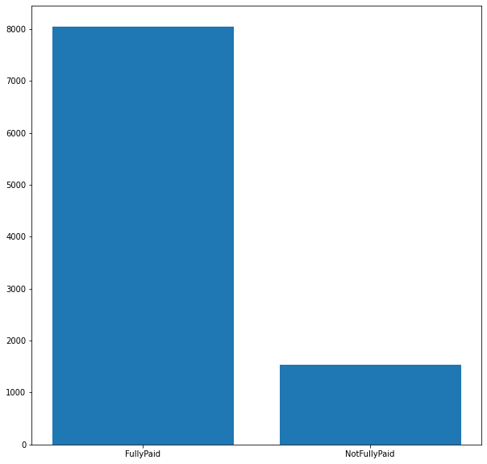

```python
# fullyPaid = loan_df['not.fully.paid'].value_counts()[0]
# notFullyPaid = loan_df['not.fully.paid'].value_counts()[1]
plt.bar(("FullyPaid", "NotFullyPaid"), loan_df['not.fully.paid'].value_counts())
```

**Dataset is clearly found to be imbalanced from above graph**

out of 9578 - 8045 people has paid the loan fully and only 1533 people haven't paid fully

So, Oversampling is required inorder to remove the biasness by algorithm towards the FullyPaid customer (notfullypaid=0)

**2.7 Assign Features and label**

```python
X = loan_df.drop('not.fully.paid', axis=1)
X.head()
```

|  | credit.policy | purpose | int.rate | installment | log.annual.inc | dti | fico | days.with.cr.line | revol.bal | revol.util | inq.last.6mths | delinq.2yrs | pub.rec |
| --- | --- | --- | --- | --- | --- | --- | --- | --- | --- | --- | --- | --- | --- |
| 0 | 1 | 2 | 0.1189 | 829.10 | 11.350407 | 19.48 | 737 | 5639.958333 | 28854 | 52.1 | 0 | 0 | 0 |
| 1 | 1 | 1 | 0.1071 | 228.22 | 11.082143 | 14.29 | 707 | 2760.000000 | 33623 | 76.7 | 0 | 0 | 0 |
| 2 | 1 | 2 | 0.1357 | 366.86 | 10.373491 | 11.63 | 682 | 4710.000000 | 3511 | 25.6 | 1 | 0 | 0 |
| 3 | 1 | 2 | 0.1008 | 162.34 | 11.350407 | 8.10 | 712 | 2699.958333 | 33667 | 73.2 | 1 | 0 | 0 |
| 4 | 1 | 1 | 0.1426 | 102.92 | 11.299732 | 14.97 | 667 | 4066.000000 | 4740 | 39.5 | 0 | 1 | 0 |

```python
y = loan_df['not.fully.paid']
y.head()
```

```
0    0
1    0
2    0
3    0
4    0
Name: not.fully.paid, dtype: int64
```

**2.8 Perform Oversampling using RandomOverSampler**

```python
sampler = RandomOverSampler(random_state=42)
```

```python
X_over_sampled, y_over_sampled = sampler.fit_sample(X, y)
```

```python
print(X_over_sampled.shape)
print(y_over_sampled.shape)
```

```
(16090, 13)
(16090,)
```

```
1    8045
0    8045
Name: not.fully.paid, dtype: int64
```

```
<BarContainer object of 2 artists>
```

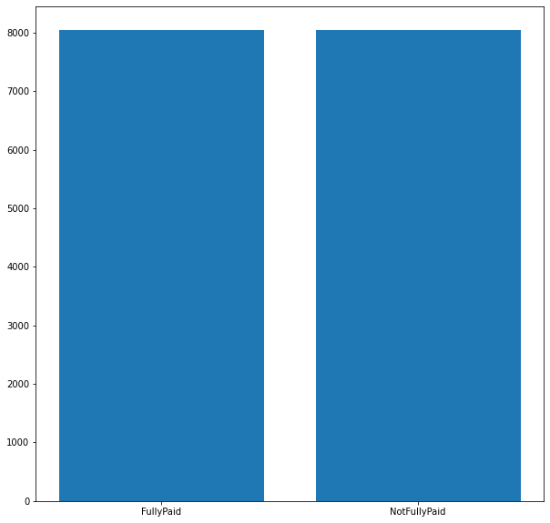

```python
print(y_over_sampled.value_counts())
plt.bar(("FullyPaid", "NotFullyPaid"), y_over_sampled.value_counts())
```

```python
print("The shape of Original dataset is", X.shape)
print("The shape of Oversampled dataset is", X_over_sampled.shape)
```

```
The shape of Original dataset is (9578, 13)
The shape of Oversampled dataset is (16090, 13)
```

**2.8 Detect Outliers in the Oversampled Dataset**

**2.8.1 To Detect Outliers - rejoin the X_oversampled and y_oversampled data**

```python
sampled_df = pd.concat([X_over_sampled, y_over_sampled], axis=1)
print("Shape of Sampled Dataframe is: ", sampled_df.shape)
sampled_df.head()
```

```
Shape of Sampled Dataframe is:  (16090, 14)
```

|  | credit.policy | purpose | int.rate | installment | log.annual.inc | dti | fico | days.with.cr.line | revol.bal | revol.util | inq.last.6mths | delinq.2yrs | pub.rec | not.fully.paid |
| --- | --- | --- | --- | --- | --- | --- | --- | --- | --- | --- | --- | --- | --- | --- |
| 0 | 1 | 2 | 0.1189 | 829.10 | 11.350407 | 19.48 | 737 | 5639.958333 | 28854 | 52.1 | 0 | 0 | 0 | 0 |
| 1 | 1 | 1 | 0.1071 | 228.22 | 11.082143 | 14.29 | 707 | 2760.000000 | 33623 | 76.7 | 0 | 0 | 0 | 0 |
| 2 | 1 | 2 | 0.1357 | 366.86 | 10.373491 | 11.63 | 682 | 4710.000000 | 3511 | 25.6 | 1 | 0 | 0 | 0 |
| 3 | 1 | 2 | 0.1008 | 162.34 | 11.350407 | 8.10 | 712 | 2699.958333 | 33667 | 73.2 | 1 | 0 | 0 | 0 |
| 4 | 1 | 1 | 0.1426 | 102.92 | 11.299732 | 14.97 | 667 | 4066.000000 | 4740 | 39.5 | 0 | 1 | 0 | 0 |

```python
sampled_df_copy = sampled_df.copy()
```

**2.8.2 Check and remove Outliers using boxplot**

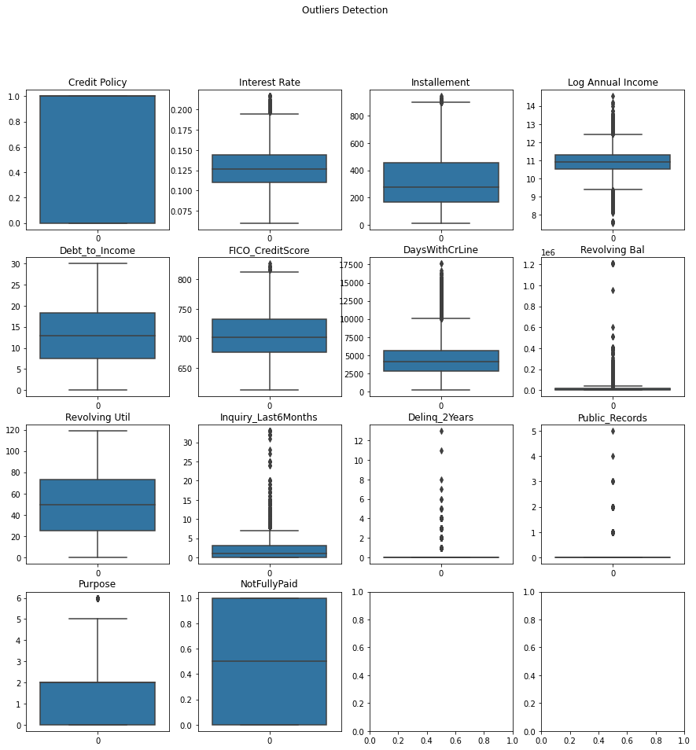

```python
fig, axes = plt.subplots(4, 4, figsize=(15, 15))
fig.suptitle('Outliers Detection')
sns.boxplot(ax=axes[0, 0], data = sampled_df['credit.policy']).set_title("Credit Policy")
sns.boxplot(ax=axes[0, 1], data = sampled_df['int.rate']).set_title("Interest Rate")
sns.boxplot(ax=axes[0, 2], data = sampled_df['installment']).set_title("Installement")
sns.boxplot(ax=axes[0, 3], data = sampled_df['log.annual.inc']).set_title("Log Annual Income")
sns.boxplot(ax=axes[1, 0], data = sampled_df['dti']).set_title("Debt_to_Income")
sns.boxplot(ax=axes[1, 1], data = sampled_df['fico']).set_title("FICO_CreditScore")
sns.boxplot(ax=axes[1, 2], data = sampled_df['days.with.cr.line']).set_title("DaysWithCrLine")
sns.boxplot(ax=axes[1, 3], data = sampled_df['revol.bal']).set_title("Revolving Bal")
sns.boxplot(ax=axes[2, 0], data = sampled_df['revol.util']).set_title("Revolving Util")
sns.boxplot(ax=axes[2, 1], data = sampled_df['inq.last.6mths']).set_title("Inquiry_Last6Months")
sns.boxplot(ax=axes[2, 2], data = sampled_df['delinq.2yrs']).set_title("Delinq_2Years")
sns.boxplot(ax=axes[2, 3], data = sampled_df['pub.rec']).set_title("Public_Records")
sns.boxplot(ax=axes[3, 0], data = sampled_df['purpose']).set_title("Purpose")
sns.boxplot(ax=axes[3, 1], data = sampled_df['not.fully.paid']).set_title("NotFullyPaid")
```

**Treating the Outliers**

```python
def outlier_treatment(datacolumn):
    sorted(datacolumn)
    Q1,Q3 = np.percentile(datacolumn,[25,75])
    IQR = Q3-Q1
    lower_range = Q1 - (1.5*IQR)
    upper_range = Q3 + (1.5*IQR)
    return lower_range,upper_range
```

Outliers Treatment has no much Impact, delinq.2yrs and pub.rec are becoming NAN after treament. So, Not treating the outliers

```python
# l,u = outlier_treatment(sampled_df["int.rate"])
# sampled_df[(sampled_df["int.rate"] > u) | (sampled_df["int.rate"] < l)]
# sampled_df.drop(sampled_df[(sampled_df["int.rate"] > u) | (sampled_df["int.rate"] < l)].index,inplace=True)
# #139 rows
# l,u = outlier_treatment(sampled_df["installment"])
# sampled_df[(sampled_df["installment"] > u) | (sampled_df["installment"] < l)]
# sampled_df.drop(sampled_df[(sampled_df["installment"] > u) | (sampled_df["installment"] < l)].index,inplace=True)
# # 100 rows
# l,u = outlier_treatment(sampled_df["log.annual.inc"])
# sampled_df[(sampled_df["log.annual.inc"] > u) | (sampled_df["log.annual.inc"] < l)]
# sampled_df.drop(sampled_df[(sampled_df["log.annual.inc"] > u) | (sampled_df["log.annual.inc"] < l)].index,inplace=True)
# # 362 rows
# l,u = outlier_treatment(sampled_df["fico"])
# sampled_df[(sampled_df["fico"] > u) | (sampled_df["fico"] < l)].shape
# sampled_df.drop(sampled_df[(sampled_df["fico"] > u) | (sampled_df["fico"] < l)].index,inplace=True)
# # 18 rows
# l,u = outlier_treatment(sampled_df["days.with.cr.line"])
# sampled_df[(sampled_df["days.with.cr.line"] > u) | (sampled_df["days.with.cr.line"] < l)].shape
# sampled_df.drop(sampled_df[(sampled_df["days.with.cr.line"] > u) | (sampled_df["days.with.cr.line"] < l)].index,inplace=True)
# # 555 rows
# l,u = outlier_treatment(sampled_df["revol.bal"])
# sampled_df[(sampled_df["revol.bal"] > u) | (sampled_df["revol.bal"] < l)].shape
# sampled_df.drop(sampled_df[(sampled_df["revol.bal"] > u) | (sampled_df["revol.bal"] < l)].index,inplace=True)
# # 1416 rows
# l,u = outlier_treatment(sampled_df["inq.last.6mths"])
# sampled_df[(sampled_df["inq.last.6mths"] > u) | (sampled_df["inq.last.6mths"] < l)].shape
# sampled_df.drop(sampled_df[(sampled_df["inq.last.6mths"] > u) | (sampled_df["inq.last.6mths"] < l)].index,inplace=True)
# 527 rows
# l,u = outlier_treatment(sampled_df["delinq.2yrs"])
# sampled_df[(sampled_df["delinq.2yrs"] > u) | (sampled_df["delinq.2yrs"] < l)].shape
# sampled_df.drop(sampled_df[(sampled_df["delinq.2yrs"] > u) | (sampled_df["delinq.2yrs"] < l)].index,inplace=True)
# # 1963 rows
# l,u = outlier_treatment(sampled_df["pub.rec"])
# sampled_df[(sampled_df["pub.rec"] > u) | (sampled_df["pub.rec"] < l)].shape
# sampled_df.drop(sampled_df[(sampled_df["pub.rec"] > u) | (sampled_df["pub.rec"] < l)].index,inplace=True)
# # 1145 rows
# l,u = outlier_treatment(sampled_df["purpose"])
# sampled_df[(sampled_df["purpose"] > u) | (sampled_df["purpose"] < l)].shape
# sampled_df.drop(sampled_df[(sampled_df["purpose"] > u) | (sampled_df["purpose"] < l)].index,inplace=True)
# # 1337 rows
```

```python
sampled_df.shape
```

```
(16090, 14)
```

**2.9 Assign the dependent label and Independent features again from sampled and outlier treated data**

```python
X_over_sampled = sampled_df.drop('not.fully.paid', axis=1)
y_over_sampled = sampled_df['not.fully.paid']
```

```python
print(X_over_sampled.shape)
print(y_over_sampled.shape)
```

```
(16090, 13)
(16090,)
```

**2.10 Check if the dataset is imbalanced after the outliers are removed from sampled data**

```python
# print(y_over_sampled.value_counts())
# plt.bar(("FullyPaid", "NotFullyPaid"), y_over_sampled.value_counts())
```

**2.11 Perform Train Test Split of the data**

```python
X_train, X_test, y_train, y_test = train_test_split(X_over_sampled,y_over_sampled, test_size=0.30, random_state=42)
```

```python
print(X_train.shape)
print(X_test.shape)
print(y_train.shape)
print(y_test.shape)
```

```
(11263, 13)
(4827, 13)
(11263,)
(4827,)
```

**2.12 Perform Standardization using Standard Scaler**

```python
from sklearn.preprocessing import StandardScaler
```

```python
scaler = StandardScaler()
```

**Applying fit on Train Data**

```python
scaler.fit(X_train)
X_train_scaled = scaler.transform(X_train)
```

**Applying Transform without fit for Test Data**

```python
X_test_scaled = scaler.transform(X_test)
```

```python
print(X_train_scaled.shape)
print(X_test_scaled.shape)
```

```
(11263, 13)
(4827, 13)
```

### **Step 3. Feature Engineering**

**3.1 Feature Engineering using Correlation**

```python
sampled_df.corr()
```

|  | credit.policy | purpose | int.rate | installment | log.annual.inc | dti | fico | days.with.cr.line | revol.bal | revol.util | inq.last.6mths | delinq.2yrs | pub.rec | not.fully.paid |
| --- | --- | --- | --- | --- | --- | --- | --- | --- | --- | --- | --- | --- | --- | --- |
| credit.policy | 1.000000 | 0.016951 | -0.286761 | 0.050919 | 0.019125 | -0.090719 | 0.371264 | 0.109544 | -0.176510 | -0.087100 | -0.540411 | -0.062096 | -0.057081 | -0.197046 |
| purpose | 0.016951 | 1.000000 | 0.138771 | 0.211918 | 0.124596 | -0.054517 | 0.069898 | 0.067324 | 0.061231 | -0.080684 | 0.047405 | 0.003205 | 0.010630 | 0.059746 |
| int.rate | -0.286761 | 0.138771 | 1.000000 | 0.269195 | 0.082992 | 0.202168 | -0.682194 | -0.112010 | 0.077827 | 0.423886 | 0.183928 | 0.144630 | 0.107155 | 0.215874 |
| installment | 0.050919 | 0.211918 | 0.269195 | 1.000000 | 0.479625 | 0.033582 | 0.109620 | 0.194459 | 0.244933 | 0.055947 | -0.003804 | 0.000359 | -0.034339 | 0.059783 |
| log.annual.inc | 0.019125 | 0.124596 | 0.082992 | 0.479625 | 1.000000 | -0.032237 | 0.107600 | 0.351122 | 0.374387 | 0.071787 | 0.043998 | 0.028143 | 0.011696 | -0.053177 |
| dti | -0.090719 | -0.054517 | 0.202168 | 0.033582 | -0.032237 | 1.000000 | -0.221844 | 0.088069 | 0.146485 | 0.326387 | 0.030524 | -0.034776 | 0.025163 | 0.051964 |
| fico | 0.371264 | 0.069898 | -0.682194 | 0.109620 | 0.107600 | -0.221844 | 1.000000 | 0.265073 | 0.003571 | -0.501385 | -0.188331 | -0.203227 | -0.154982 | -0.204929 |
| days.with.cr.line | 0.109544 | 0.067324 | -0.112010 | 0.194459 | 0.351122 | 0.088069 | 0.265073 | 1.000000 | 0.240694 | 0.011517 | -0.031798 | 0.081435 | 0.067153 | -0.040445 |
| revol.bal | -0.176510 | 0.061231 | 0.077827 | 0.244933 | 0.374387 | 0.146485 | 0.003571 | 0.240694 | 1.000000 | 0.154683 | 0.042413 | -0.019313 | -0.034489 | 0.056710 |
| revol.util | -0.087100 | -0.080684 | 0.423886 | 0.055947 | 0.071787 | 0.326387 | -0.501385 | 0.011517 | 0.154683 | 1.000000 | -0.029071 | -0.047815 | 0.075139 | 0.101486 |
| inq.last.6mths | -0.540411 | 0.047405 | 0.183928 | -0.003804 | 0.043998 | 0.030524 | -0.188331 | -0.031798 | 0.042413 | -0.029071 | 1.000000 | 0.003208 | 0.093896 | 0.172950 |
| delinq.2yrs | -0.062096 | 0.003205 | 0.144630 | 0.000359 | 0.028143 | -0.034776 | -0.203227 | 0.081435 | -0.019313 | -0.047815 | 0.003208 | 1.000000 | -0.008630 | 0.010338 |
| pub.rec | -0.057081 | 0.010630 | 0.107155 | -0.034339 | 0.011696 | 0.025163 | -0.154982 | 0.067153 | -0.034489 | 0.075139 | 0.093896 | -0.008630 | 1.000000 | 0.062588 |
| not.fully.paid | -0.197046 | 0.059746 | 0.215874 | 0.059783 | -0.053177 | 0.051964 | -0.204929 | -0.040445 | 0.056710 | 0.101486 | 0.172950 | 0.010338 | 0.062588 | 1.000000 |

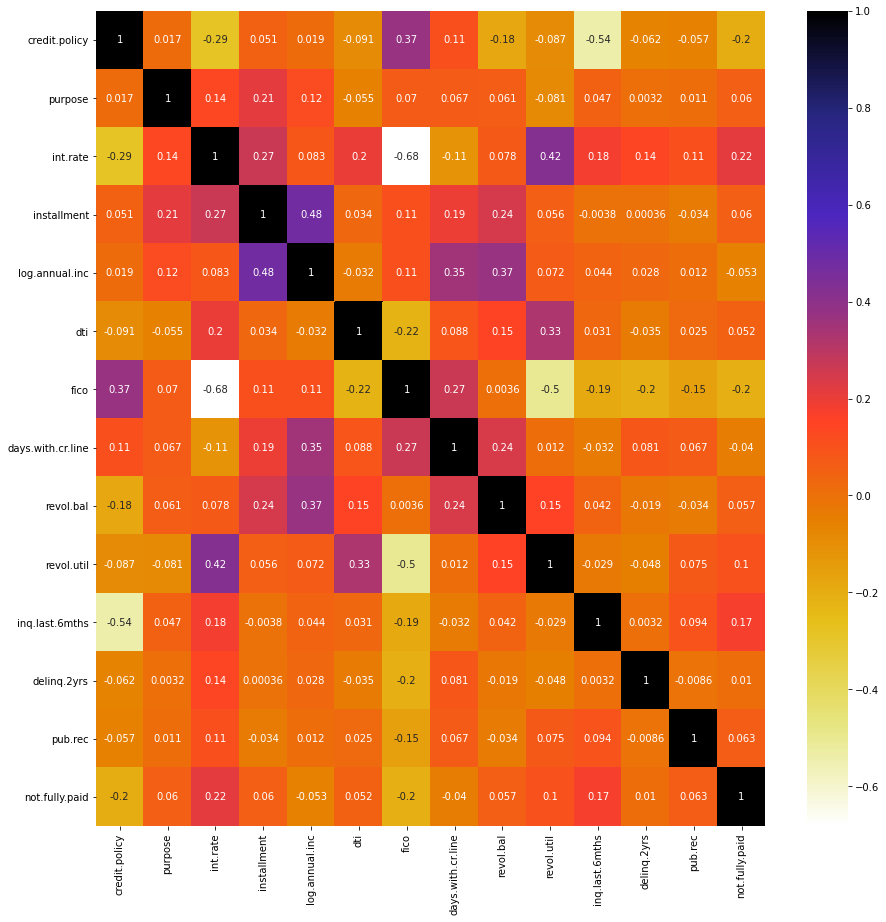

```python
plt.figure(figsize=(15,15))
sns.heatmap(sampled_df.corr(), annot=True, cmap = plt.cm.CMRmap_r)
```

```python
def correlation(dataset, threshold):
    col_corr = set()
    corr_matrix = dataset.corr()
    for i in range(len(corr_matrix.columns)):
        for j in range(i):
            if(corr_matrix.iloc[i,j] > threshold):
                colname = corr_matrix.columns[i]
                col_corr.add(colname)
    return col_corr
```

**Apply the above correlation check on Training data only as we should not perform correlaton check on test data**

```python
corr_features = correlation(X_train, 0.7)
len(set(corr_features))
```

```
0
```

Correlation below 0.3 are considered to be weak; 0.3-0.7 are moderate; >0.7 are strong

#### There are no strongly correlated features in the data

**3.2 Feature selection using PCA**

[figure not shown]

```python
from sklearn.decomposition import PCA
pca = PCA()
pca.fit(X_train_scaled)
cumsum = np.cumsum(pca.explained_variance_ratio_)*100
d = [n for n in range(len(cumsum))]
plt.figure(figsize=(10, 10))
plt.plot(d,cumsum, color = 'red',label='cumulative explained variance')
plt.title('Cumulative Explained Variance as a Function of the Number of Components')
plt.ylabel('Cumulative Explained variance')
plt.grid(axis='x')
plt.xlabel('Principal Components')
plt.axhline(y = 98, color='k', linestyle='--', label = '95% Explained Variance')
plt.legend(loc='best')
```

```python
pca = PCA(n_components=0.98)
pca.fit(X_train_scaled)
print(pca.explained_variance_ratio_.size)
X_train_scaled = pca.transform(X_train_scaled)
print(X_train_scaled.shape)
X_test_scaled = pca.transform(X_test_scaled)
print(X_test_scaled.shape)
```

```
12
(11263, 12)
(4827, 12)
```

### **Step 4. Build Models**

**Build Machine Learning Models before a Deep Learning Model to compare the accuracy**

**#1: Apply Logistic Regression**

```python
model_lr = LogisticRegression()
```

```python
model_lr.fit(X_train_scaled, y_train)
```

```
LogisticRegression(C=1.0, class_weight=None, dual=False, fit_intercept=True,
                   intercept_scaling=1, l1_ratio=None, max_iter=100,
                   multi_class='auto', n_jobs=None, penalty='l2',
                   random_state=None, solver='lbfgs', tol=0.0001, verbose=0,
                   warm_start=False)
```

```python
y_pred_lr = model_lr.predict(X_test_scaled)
```

```python
accuracy_score(y_test, y_pred_lr)
```

```
0.620261031696706
```

**#2 Apply K Nearest Neighbors Classifier Algorithm**

```python
model_knn = KNeighborsClassifier(n_neighbors=5)
```

```python
model_knn.fit(X_train_scaled,y_train)
```

```
KNeighborsClassifier(algorithm='auto', leaf_size=30, metric='minkowski',
                     metric_params=None, n_jobs=None, n_neighbors=5, p=2,
                     weights='uniform')
```

```python
y_pred_knn = model_knn.predict(X_test_scaled)
```

```python
accuracy_score(y_test, y_pred_knn)
```

```
0.7470478558110628
```

**#3 Apply Decision Tree Classification Algorithm**

```python
from sklearn.tree import DecisionTreeClassifier
```

```python
model_dtr = DecisionTreeClassifier(random_state=2)
```

```python
model_dtr.fit(X_train_scaled,y_train)
```

```
DecisionTreeClassifier(ccp_alpha=0.0, class_weight=None, criterion='gini',
                       max_depth=None, max_features=None, max_leaf_nodes=None,
                       min_impurity_decrease=0.0, min_impurity_split=None,
                       min_samples_leaf=1, min_samples_split=2,
                       min_weight_fraction_leaf=0.0, presort='deprecated',
                       random_state=2, splitter='best')
```

```python
y_pred_dtr = model_dtr.predict(X_test_scaled)
```

```python
accuracy_score(y_test, y_pred_dtr)
```

```
0.8875077688004972
```

### **Step 5. Ensemble Techniques**

```python
from sklearn.ensemble import RandomForestClassifier
```

```python
model_rfr = RandomForestClassifier(n_estimators=40, random_state=2)
```

```python
model_rfr.fit(X_train_scaled,y_train)
```

```
RandomForestClassifier(bootstrap=True, ccp_alpha=0.0, class_weight=None,
                       criterion='gini', max_depth=None, max_features='auto',
                       max_leaf_nodes=None, max_samples=None,
                       min_impurity_decrease=0.0, min_impurity_split=None,
                       min_samples_leaf=1, min_samples_split=2,
                       min_weight_fraction_leaf=0.0, n_estimators=40,
                       n_jobs=None, oob_score=False, random_state=2, verbose=0,
                       warm_start=False)
```

```python
y_pred_rfr = model_rfr.predict(X_test_scaled)
```

```python
accuracy_score(y_test, y_pred_rfr)
```

```
0.9585663973482494
```

**Importance of Features for Random Forest Classifier**

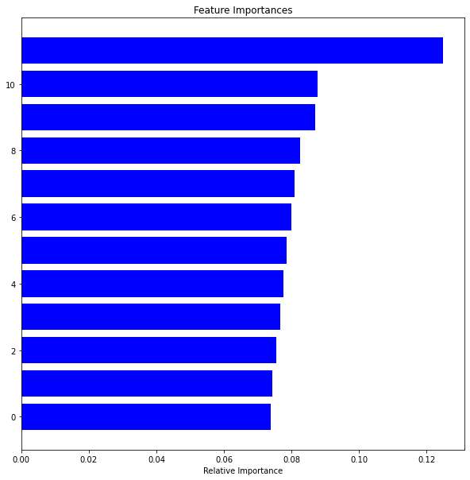

```python
# features = X_train_scaled.columns   --- Which columns are picked in PCA, order of columns, we are not aware - So not plotting Features Names
importances = model_rfr.feature_importances_
indices = np.argsort(importances)[-50:]  # top 50 features
plt.title('Feature Importances')
plt.barh(range(len(indices)), importances[indices], color='b', align='center')
# plt.yticks(range(len(indices)), [features[i] for i in indices])
plt.xlabel('Relative Importance')
plt.show()
```

```python
X_train_scaled.shape[1]
```

```
12
```

### **Deep Learning Model using Keras with Tensor Flow backend**

```
Train on 11263 samples, validate on 4827 samples
   val_loss  val_accuracy      loss  accuracy
0  0.649788      0.626476  0.668521  0.591849
1  0.642175      0.631655  0.651196  0.617686
2  0.639743      0.633727  0.645354  0.627275
3  0.636164      0.631655  0.640819  0.631182
4  0.634715      0.638492  0.638979  0.635355
```

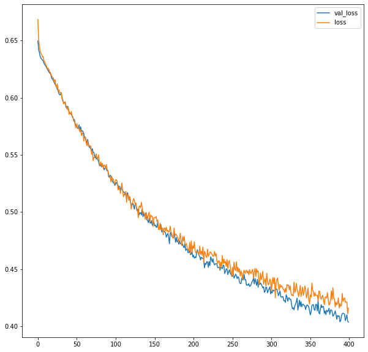

```python
model = Sequential()
model.add(Dense(60, input_dim=X_train_scaled.shape[1], activation='relu'))
model.add(Dropout(0.2))
model.add(Dense(120, activation='relu'))
model.add(Dropout(0.2))
model.add(Dense(60, activation='relu'))
model.add(Dropout(0.2))
model.add(Dense(1, activation='sigmoid'))
model.compile(loss='binary_crossentropy', optimizer='adam', metrics=['accuracy'])
model.fit(X_train_scaled, y_train, epochs=400, batch_size=256, validation_data=(X_test_scaled, y_test))
loss_df = pd.DataFrame(model.history.history)
print(loss_df.head())
loss_df[['val_loss', 'loss']].plot()
```

```python
predictions = model.predict_classes(X_test_scaled)
print("With the above hyperparameter tuning I'm able to acheive {}% accuracy".format(np.round((accuracy_score(y_test, predictions)*100), 2)))
```

```
With the above hyperparameter tuning I'm able to acheive 81.87% accuracy
```

```python
# 0.7663144810441268 - 128 batch size

# 0.7418686554795939 - 256 batch size

# 6 layers + 2 dropouts - 0.8537393826393205

#2 layers + 0 dropouts - 0.8844002486016159
```

```python
#With 150 Epochs - accuracy is 0.9051170499274912

# With 400 Epochs also we are not seeing any improvement in accuracy
```

Computation time for the below Stratified KFold is too high and % accuracy is very less

```python
# from sklearn.model_selection import StratifiedKFold
# kfold = StratifiedKFold(n_splits=10, shuffle=True, random_state=7)
# cvscores = []
# y_over_sampled = pd.DataFrame(y_over_sampled, columns=['not.fully.paid'])
# for train, test in kfold.split(X_over_sampled, y_over_sampled):
#     X_K_train = X_over_sampled.loc[(train),:]
#     y_K_train = y_over_sampled.loc[(train),:]
#     X_K_test = X_over_sampled.loc[(test),:]
#     y_K_test = y_over_sampled.loc[(test),:]
#     #create model
#     model = Sequential()
#     model.add(Dense(32, input_dim=13, activation='relu'))
#     model.add(Dense(16, activation='relu'))
#     model.add(Dense(1, activation='sigmoid'))
#     # Compile model
#     model.compile(loss='binary_crossentropy', optimizer='adam', metrics=['accuracy'])
#     # Fit the model
#     model.fit(X_K_train, y_K_train, epochs=150, batch_size=10, verbose=0)
#     # evaluate the model
#     scores = model.evaluate(X_K_test, y_K_test, verbose=0)
#     print("%s: %.2f%%" % (model.metrics_names[1], scores[1]*100))
#     cvscores.append(scores[1] * 100)
```

```python
# Output:

# accuracy: 50.59%
# accuracy: 50.03%
# accuracy: 49.97%
# accuracy: 50.03%
# accuracy: 49.97%
# accuracy: 51.52%
# accuracy: 50.34%
# accuracy: 50.47%
# accuracy: 50.22%
# accuracy: 50.16%
```

```python
# print("%.2f%% (+/- %.2f%%)" % (np.mean(cvscores), np.std(cvscores)))
```

```python
# Output: 50.33% (+/- 0.45%)
```